# Trabalho 1 Séries temporais

## Sobre os dados

Nosso conjunto de dados é referente aos financiamentos feitos pelo Banco Nacional do Desenvolvimento (BNDES) de forma indireta, ou seja, o cliente solicita o financiamento por meio de uma instituição financeira credenciada e não diretamente ao BNDES

No financiamento indireto pois quem assue o risco do não pagamento passa a ser a instituição financeira credenciada em questão, que também negocia os prazos e condições do financiamento, assim como cabe a ela aceitar ou não o financiamento.

O financiamento indireto pode ser feita de forma automática, ou seja, que não precisa passar por homologação do BNDES ou não automática, aonde o banco avalia cada solicitação individualmente. Para o financiamento não automático há um valor mínimo de 20 milhões de reais.

Nossa base de dados consiste de informações de financiamentos indiretos de forma não automática informados pelo BNDES entre janeiro de 2017 a janeiro de 2024 2024. Nossa planilha originalmente constava com detalhes de 321272 operações. Para esse trabalho agregamos o número de operações e analisaremos elas em caráter mensal.

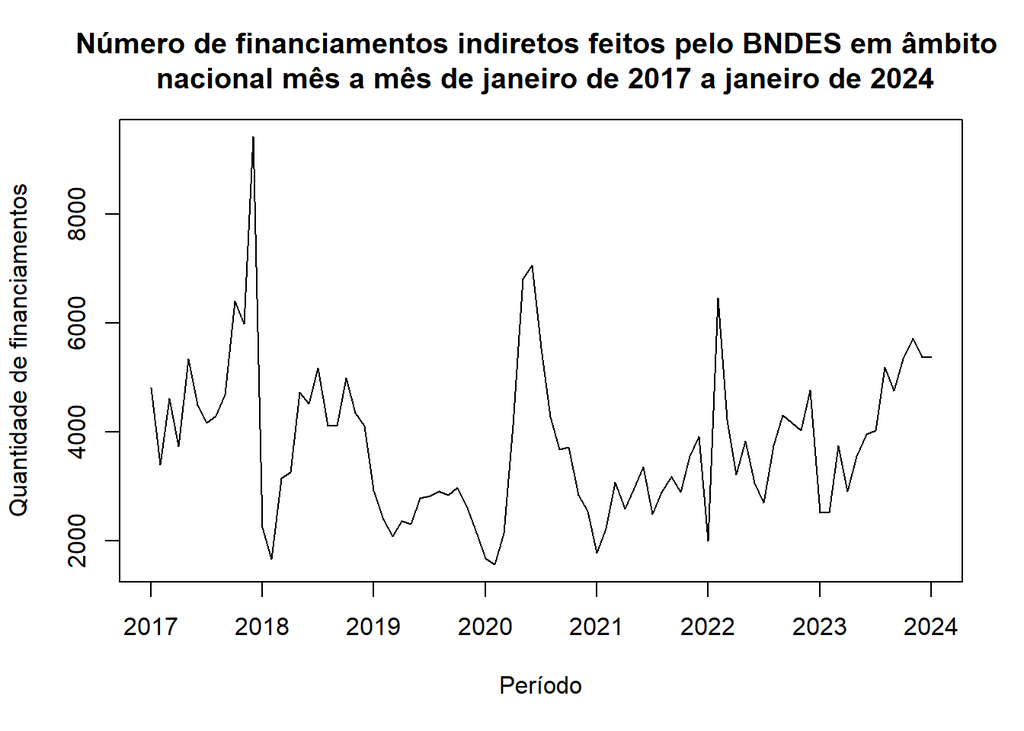

```r
library(readr)

dados <-  read_csv("dados_series.csv")
dados <-  dados$V1

serie <-  ts(dados, start = c(2017,1), end = c(2024, 1), frequency = 12 )

plot(serie, main = "Número de financiamentos indiretos feitos pelo BNDES em âmbito \n nacional mês a mês de janeiro de 2017 a janeiro de 2024", xlab = "Período", ylab = "Quantidade de financiamentos")
```

```r
#usando a media
dados[12] <-  (dados[11] + dados[13])/2
dados[60] <-  (dados[59] + dados[61])/2
serie <-  ts(dados, start = c(2017,1), end = c(2024, 1), frequency = 12 )
```

## FAC E FACP

```r
library(forecast)
```

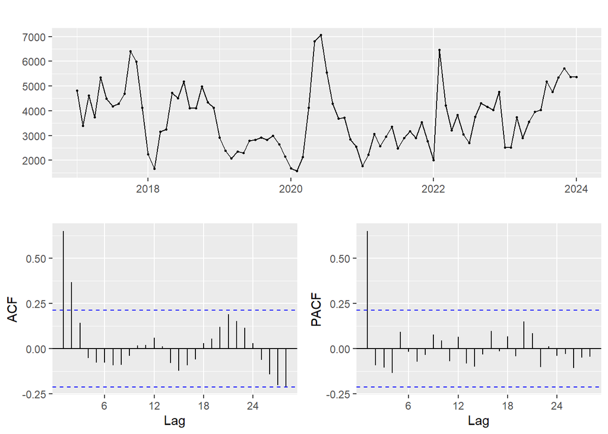

```r
ggtsdisplay(serie)
```

Usamos AR(1)

```r
modelo1 <- Arima(serie, order = c(1,0,0))
modelo1
```

```
## Series: serie
## ARIMA(1,0,0) with non-zero mean
##
## Coefficients:
##          ar1      mean
##       0.6628  3765.027
## s.e.  0.0814   295.753
##
## sigma^2 = 901260:  log likelihood = -702.63
## AIC=1411.26   AICc=1411.55   BIC=1418.58
```

### Teste de significância

```r
library(lmtest)
coeftest(modelo1)
```

```
##
## z test of coefficients:
##
##             Estimate Std. Error z value  Pr(>|z|)
## ar1       6.6277e-01 8.1401e-02   8.142 3.887e-16 ***
## intercept 3.7650e+03 2.9575e+02  12.730 < 2.2e-16 ***
## ---
## Signif. codes:  0 '***' 0.001 '**' 0.01 '*' 0.05 '.' 0.1 ' ' 1
```

### sobrefixando

```r
#AR(2)
modelo3 <- Arima(serie, order = c(2,0,0))
modelo3
```

```
## Series: serie
## ARIMA(2,0,0) with non-zero mean
##
## Coefficients:
##          ar1      ar2       mean
##       0.7282  -0.0992  3753.1383
## s.e.  0.1085   0.1093   269.2495
##
## sigma^2 = 903299:  log likelihood = -702.22
## AIC=1412.44   AICc=1412.94   BIC=1422.21
```

```r
coeftest(modelo3)
```

```
##
## z test of coefficients:
##
##              Estimate  Std. Error z value  Pr(>|z|)
## ar1          0.728171    0.108494  6.7116 1.925e-11 ***
## ar2         -0.099188    0.109306 -0.9074    0.3642
## intercept 3753.138291  269.249455 13.9393 < 2.2e-16 ***
## ---
## Signif. codes:  0 '***' 0.001 '**' 0.01 '*' 0.05 '.' 0.1 ' ' 1
```

Piorou o ajuste dos coeficientes

```r
#ARMA(1,1)
modelo4 <- Arima(serie, order = c(1,0,1))
modelo4
```

```
## Series: serie
## ARIMA(1,0,1) with non-zero mean
##
## Coefficients:
##          ar1     ma1       mean
##       0.5921  0.1279  3756.7299
## s.e.  0.1293  0.1579   275.8591
##
## sigma^2 = 904772:  log likelihood = -702.29
## AIC=1412.57   AICc=1413.07   BIC=1422.34
```

```r
coeftest(modelo4)
```

```
##
## z test of coefficients:
##
##             Estimate Std. Error z value  Pr(>|z|)
## ar1          0.59207    0.12929  4.5794 4.663e-06 ***
## ma1          0.12790    0.15787  0.8101    0.4179
## intercept 3756.72986  275.85910 13.6183 < 2.2e-16 ***
## ---
## Signif. codes:  0 '***' 0.001 '**' 0.01 '*' 0.05 '.' 0.1 ' ' 1
```

Piorou tambem.

Assim, nosso modelo escolhido foi o AR(1)

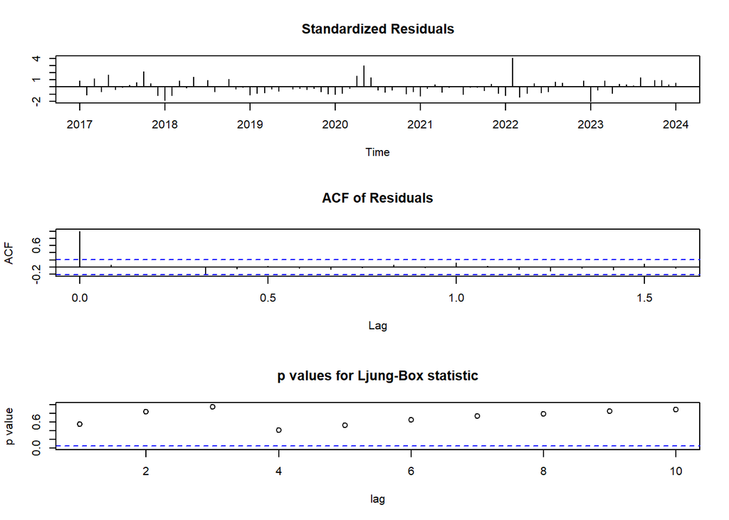

```r
tsdiag(modelo1)
```

Todos os p-valores são maiores que 0.05 o que nos leva a não rejeitar a hipótese de erros serem um ruído branco a este nível de significância.

## bibliografia

- BNDES. Formas de apoio. https://www.bndes.gov.br/wps/portal/site/home/financiamento/guia/Formas-de-Apoio [Acesso em 10/04/2024]